# Predicting Face Features

Zarrar Shehzad

March 4, 2017

We visualize predicting different face features (e.g., traits and age) using the shape/texture PCA components.

# Setup

```r
# Path for my own packages
if (!any(.libPaths() == "/home/zshehzad/R/x86_64-redhat-linux-gnu-library/3.2")) .libPaths(c("/home/zshehzad/R/x86_64-redhat-linux-gnu-library/3.2", .libPaths()))
if (!any(.libPaths() == "/home/zshehzad/R_libs")) .libPaths(c("~/R_libs", .libPaths()))

# General workhorse function
library(plyr)

# Parallelization
suppressMessages(library(doMC))
registerDoMC(24)

# If we were to use ggplot2 and other plotting needs
library(RColorBrewer)
library(ggplot2)
source("/data1/famface01/command/encoding/FirstPass/plot_functions.R")

# This gets us the simple_lm function for faster GLMs
source("/data1/famface01/command/encoding/SubRois_Unfam/lm_functions.R")
```

## Load

```r
load("/data1/famface01/analysis/misc/320_roi_task_activity/40_predict_face_feats_df.rda", verbose=T)
```

```
## Loading objects:
##   vnames
##   df2
##   cvrep.gaussian
##   cvrep.multinomial
##   cvrep.binomial
```

# Visualize

## Fits

### Gaussian

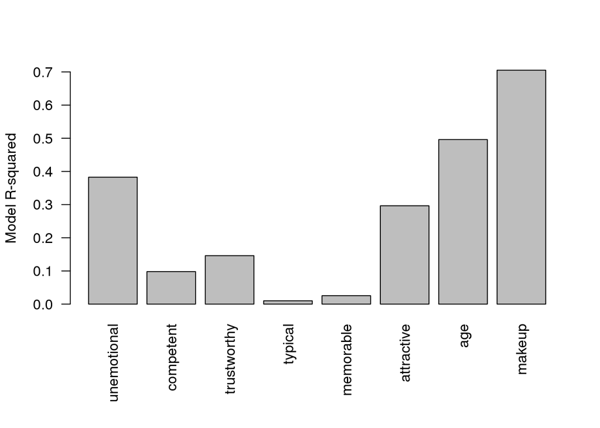

```r
rsqs <- sapply(cvrep.gaussian, function(x) x$mean.max.res)
mar <- par()$mar; par(mar = mar + c(2,0,0,0))
barplot(rsqs, las=2, ylab="Model R-squared")
```

```r
par(mar=mar)
```

### Multinomial

Multinomial type fits. Notice that the accuracies are all significant except for the eyes. So we aren’t able to the predict eye color based on the shape/texture data. Funny that hair is even significant where eyes are not. Maybe if I ran some analysis restricting the face features to just the eyes, it would do better. Note that most of the time the data, chooses the baseline or largest class.

```r
df.acc <- ldply(names(cvrep.multinomial), function(name) {
  confmat <- caret::confusionMatrix(cvrep.multinomial[[name]]$fitted.class, df2[[name]])
  c(name=name, confmat$overall)
})
df.acc1 <- df.acc
print(df.acc)
```

```
##          name          Accuracy             Kappa     AccuracyLower
## 1 facial_hair 0.850694444444444 0.521514585614012 0.825159723693727
## 2        race 0.854166666666667  0.44203782481677 0.828848832620484
## 3         eye 0.666666666666667 0.189424787121069 0.634127153373826
## 4        hair 0.517361111111111 0.277290561738251 0.483452000578086
##       AccuracyUpper      AccuracyNull       AccuracyPValue
## 1 0.873808806223618 0.800925925925926 9.23114218463044e-05
## 2 0.877039452920506 0.810185185185185 0.000403606798017997
## 3 0.698064462219461 0.710648148148148    0.997835506656463
## 4 0.551151449785078 0.438657407407407 2.02862505247256e-06
##          McnemarPValue
## 1 0.000280996986624993
## 2                  NaN
## 3 0.000713941171550577
## 4                  NaN
```

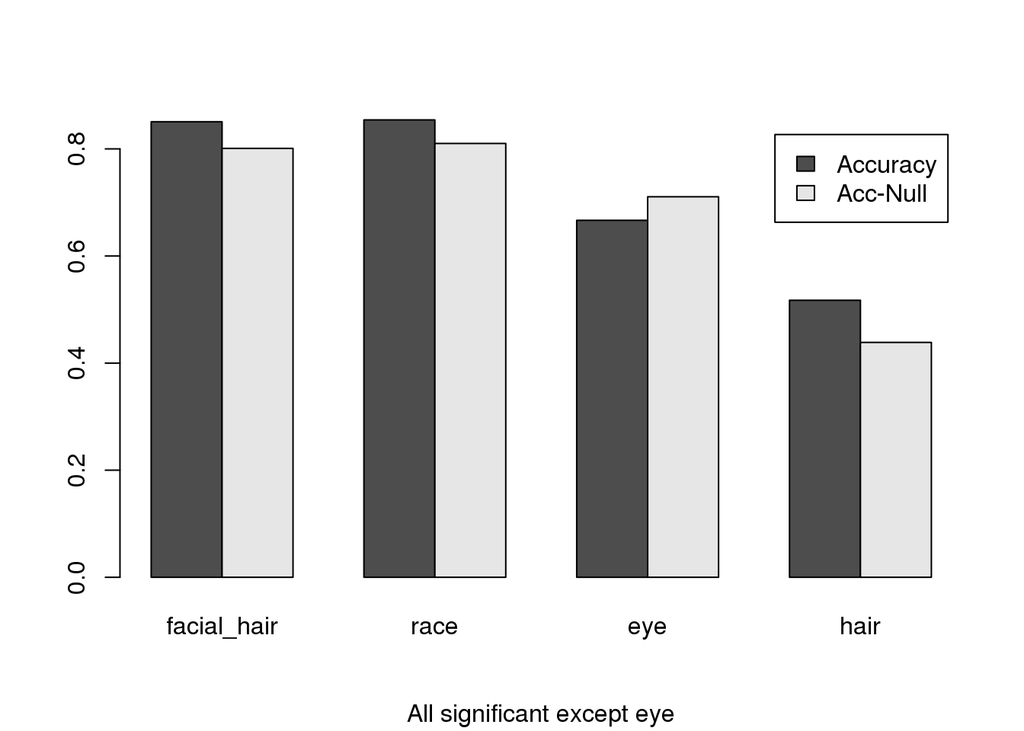

```r
sdf <- as.matrix(subset(df.acc, select=c("Accuracy", "AccuracyNull")))
sdf <- matrix(as.numeric(sdf), nrow(sdf), ncol(sdf))
dimnames(sdf) <- list(measure=names(cvrep.multinomial), c("Accuracy", "Acc-Null"))
barplot(t(sdf), beside=T, legend=T, sub = "All significant except eye")
```

### Binomial

Both of these binomial measures do excedingly well, especially gender.

```r
df.acc <- ldply(names(cvrep.binomial), function(name) {
  confmat <- caret::confusionMatrix(cvrep.binomial[[name]]$fitted.class, df2[[name]])
  c(name=name, confmat$overall)
})
df.acc2 <- df.acc
print(df.acc)
```

```
##      name          Accuracy             Kappa     AccuracyLower
## 1  gender 0.947916666666667 0.895833333333333 0.930926145587511
## 2 glasses  0.96412037037037 0.780495000819538 0.949456303863126
##       AccuracyUpper     AccuracyNull        AccuracyPValue
## 1 0.961759844941877              0.5 3.11507674314434e-185
## 2 0.975493808538139 0.90162037037037  2.35723481607886e-12
##       McnemarPValue
## 1                 1
## 2 0.011921001496914
```

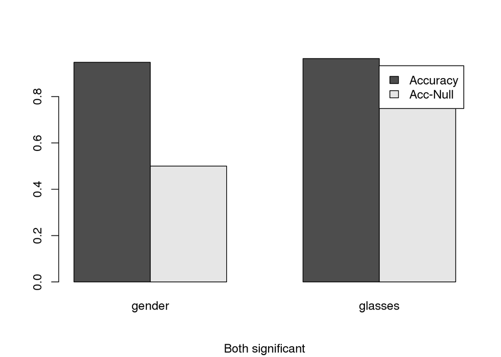

```r
sdf <- as.matrix(subset(df.acc, select=c("Accuracy", "AccuracyNull")))
sdf <- matrix(as.numeric(sdf), nrow(sdf), ncol(sdf))
dimnames(sdf) <- list(measure=names(cvrep.binomial), c("Accuracy", "Acc-Null"))
barplot(t(sdf), beside=T, legend=T, sub = "Both significant")
```

## Predicted/Residual Values

### Gaussian Fits

This will show the raw data, predicted, and residuals of the features. To make viewing easier, I have scaled each of the matrices. Also remember that the first 6 trait measures are actually factor scores. And all the rows are arranged in the same fashion, according to the raw data.

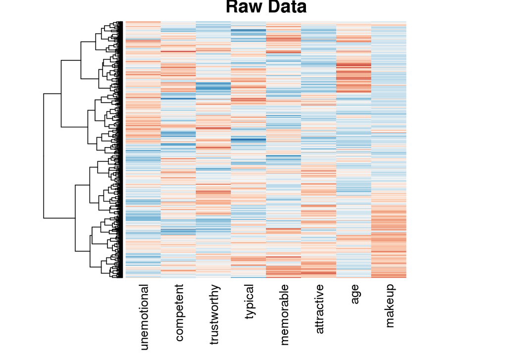

```r
# vals
predvals  <- sapply(cvrep.gaussian, function(x) x$fitted)
residvals <- sapply(cvrep.gaussian, function(x) x$resid)

# colors
cols <- rev(colorRampPalette(brewer.pal(11, "RdBu"))(100))

# arrange rows
#mat <- (scale(predvals) + scale(df2[,c(1:7,9)]))/2
mat <- scale(df2[,c(1:7,9)])
hc.rows <- hclust(dist(mat), method="ward.D2")

# Raw data
mat <- scale(df2[,c(1:7,9)])
zlim <- max(abs(mat)) * c(-1,1)
heatmap(as.matrix(mat), scale="none", col=cols,
        zlim=zlim, Colv=NA, labRow=NA, Rowv=as.dendrogram(hc.rows),
        margins=c(7,5), cexCol = 1.25, cexRow = 1.25, main="Raw Data")
```

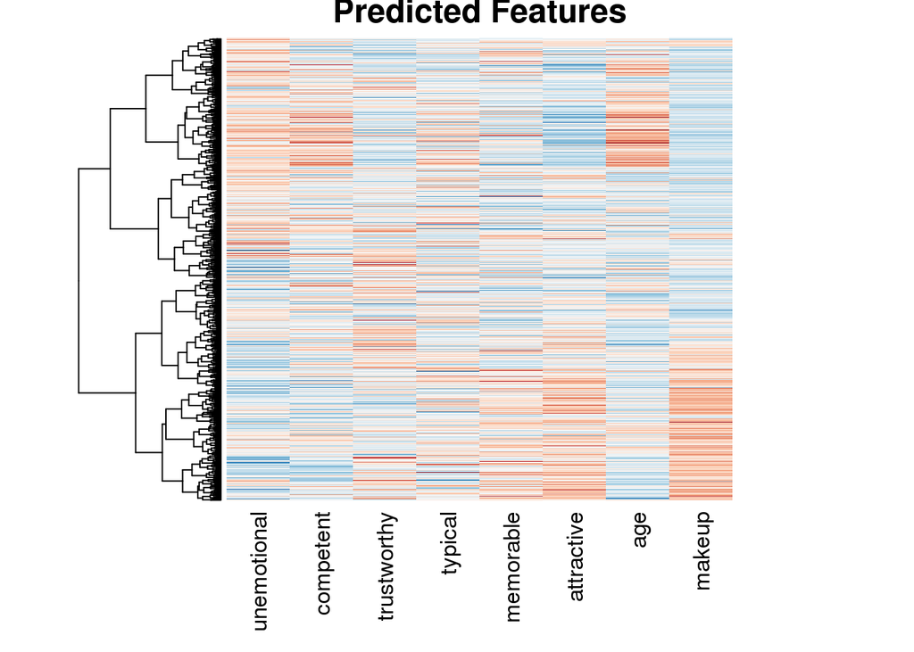

```r
# Predicted features
mat <- scale(predvals)
zlim <- max(abs(mat)) * c(-1,1)
heatmap(mat, scale="none", col=cols,
        zlim=zlim, Colv=NA, labRow=NA, Rowv=as.dendrogram(hc.rows),
        margins=c(7,5), cexCol = 1.25, cexRow = 1.25, main="Predicted Features")
```

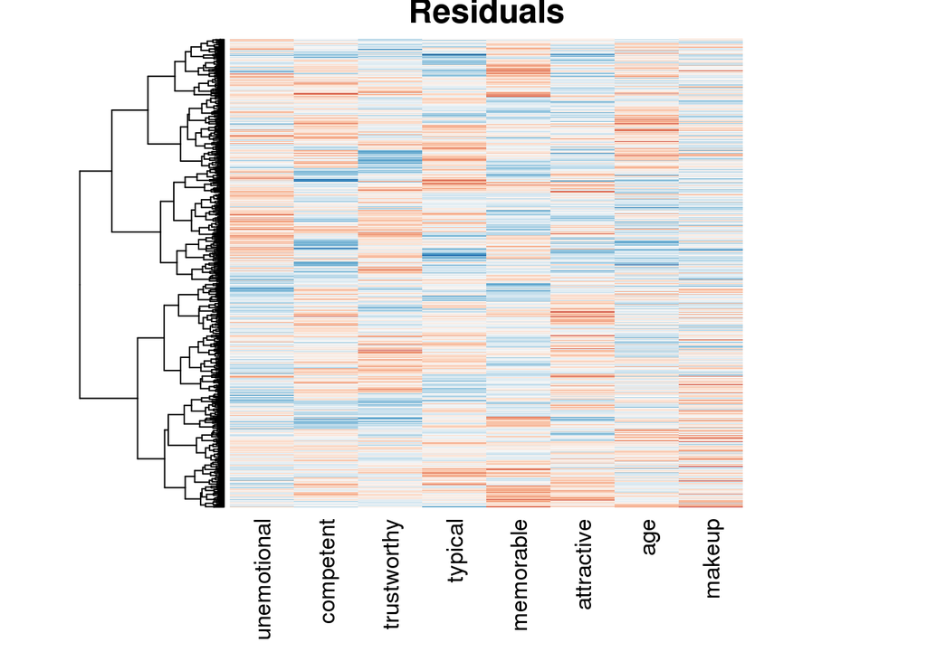

```r
# Residuals
mat <- scale(residvals)
zlim <- max(abs(mat)) * c(-1,1)
heatmap(mat, scale="none", col=cols,
        zlim=zlim, Colv=NA, labRow=NA, Rowv=as.dendrogram(hc.rows),
        margins=c(7,5), cexCol = 1.25, cexRow = 1.25, main="Residuals")
```

### Multinomial Fits

We first see what’s happening with the class labels. Again both rows are arranged according to the raw data.

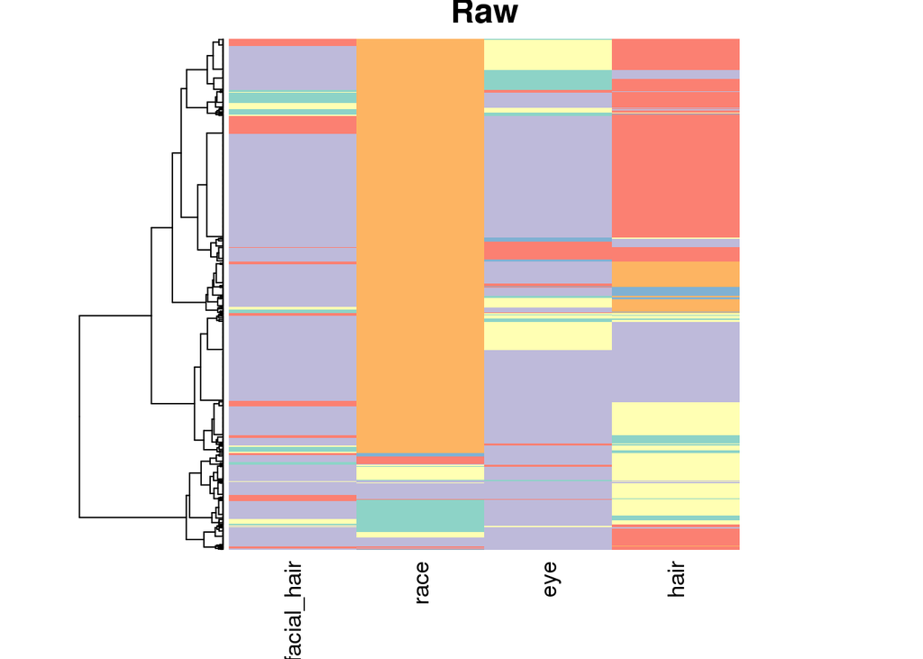

```r
predclasses1 <- predclasses <- data.frame(sapply(cvrep.multinomial, function(x) x$fitted.class))
rawclasses1  <- rawclasses  <- subset(df2, select=colnames(predclasses))

# Arrange rows
mat <- sapply(1:ncol(predclasses), function(i) as.numeric(factor(rawclasses[,i], levels=levels(rawclasses[,i]))))
hc.rows <- hclust(dist(mat), method="ward.D2")

# Raw data
mat <- sapply(1:ncol(predclasses), function(i) as.numeric(factor(rawclasses[,i], levels=levels(rawclasses[,i]))))
colnames(mat) <- colnames(predclasses)
cols <- brewer.pal(max(mat), "Set3")
heatmap(mat, scale="none", col=cols, Colv=NA, labRow=NA, Rowv=as.dendrogram(hc.rows), cexCol=1.25, main="Raw")
```

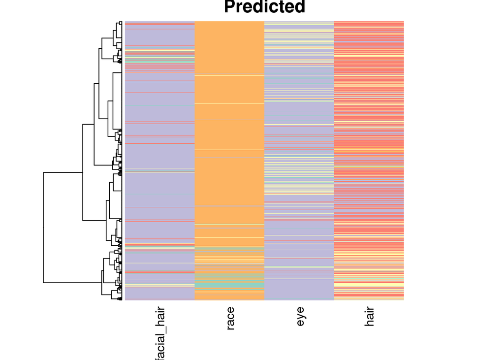

```r
# Predicted vals
mat <- sapply(1:ncol(predclasses), function(i) as.numeric(factor(predclasses[,i], levels=levels(rawclasses[,i]))))
colnames(mat) <- colnames(predclasses)
cols <- brewer.pal(max(mat), "Set3")
heatmap(mat, scale="none", col=cols, Colv=NA, labRow=NA, Rowv=as.dendrogram(hc.rows), cexCol=1.25, main="Predicted")
```

We can also take a look at the probability values. Note this expands to have each class with a separate column.

```r
predprobs1 <- predprobs <- data.frame(sapply(cvrep.multinomial, function(x) x$fitted))
residprobs1 <- residprobs <- data.frame(sapply(cvrep.multinomial, function(x) x$resids))
mn.cnames1 <- mn.cnames <- unlist(lapply(names(cvrep.multinomial), function(x) levels(df2[[x]])))
head(predprobs)
```

```
##   facial_hair.1 facial_hair.2 facial_hair.3 facial_hair.4       race.1
## 1  0.0010753979  0.0041972523    0.98952921  0.0052040590 0.2286105547
## 2  0.2948696616  0.4615181868    0.01836797  0.2252458392 0.8800143528
## 3  0.0005566596  0.0006932884    0.99850263  0.0002543592 0.0008790943
## 4  0.0027010172  0.0005569541    0.99589920  0.0008490313 0.0097480756
## 5  0.0012910972  0.0083397784    0.98828591  0.0020888488 0.1779555984
## 6  0.0672569827  0.0006560568    0.92866892  0.0034253508 0.0947158512
##         race.2      race.3       race.4       race.5     race.6
## 1 0.0087802112 0.052428308 0.0087361786 0.0052403394 0.69620441
## 2 0.0004576585 0.079176343 0.0187893616 0.0019558007 0.01960727
## 3 0.0016185978 0.002810568 0.0002853066 0.0006958606 0.99371498
## 4 0.0424951285 0.002867764 0.0013715430 0.0012350017 0.94228613
## 5 0.0854427365 0.084130489 0.0067709762 0.0123383153 0.63336189
## 6 0.2059759355 0.139006189 0.0308416155 0.0050520522 0.52440836
##          eye.1      eye.2     eye.3       eye.4        eye.5     hair.1
## 1 0.0070638974 0.16502251 0.8237163 0.003576723 0.0006205573 0.07491925
## 2 0.0162349150 0.21991922 0.7511556 0.001052754 0.0116384363 0.11665582
## 3 0.0044027233 0.01121322 0.9684322 0.013532241 0.0024196666 0.02095477
## 4 0.0402318174 0.09431682 0.8436168 0.013323249 0.0085113546 0.01944729
## 5 0.0027367228 0.16772280 0.8270796 0.001071187 0.0013897244 0.04001709
## 6 0.0001814664 0.03089942 0.9671076 0.001507512 0.0003047140 0.06190157
##       hair.2     hair.3     hair.4     hair.5      hair.6
## 1 0.15096335 0.24958526 0.28327988 0.02927731 0.211974936
## 2 0.52276383 0.07047089 0.26368038 0.01420719 0.012221889
## 3 0.02174429 0.20425523 0.71068753 0.03433310 0.008025086
## 4 0.41243571 0.03031959 0.09681369 0.01088291 0.430100812
## 5 0.54964965 0.13750863 0.16917734 0.03907432 0.064572968
## 6 0.07482796 0.17241942 0.17245519 0.02194284 0.496453035
```

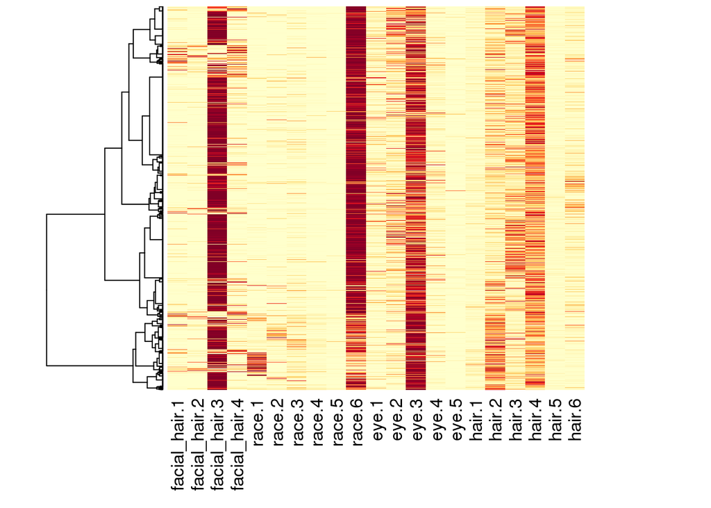

```r
cols <- colorRampPalette(brewer.pal(9, "YlOrRd"))(100)
mat <- as.matrix(predprobs)
zlim <- c(0,1)
heatmap(mat, scale="none", col=cols,
        zlim=zlim, Colv=NA, labRow=NA, Rowv=as.dendrogram(hc.rows),
        margins=c(7,5), cexCol = 1.25)
```

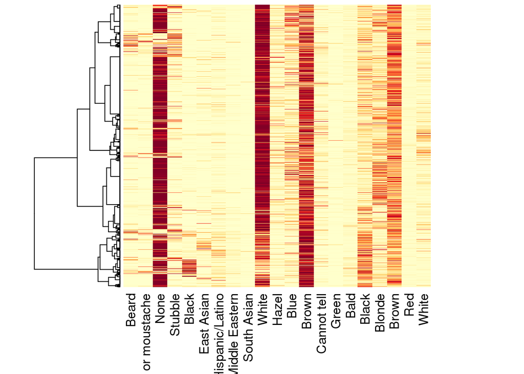

```r
heatmap(mat, scale="none", col=cols,
        zlim=zlim, Colv=NA, labCol=mn.cnames, labRow=NA, Rowv=as.dendrogram(hc.rows),
        margins=c(7,5), cexCol = 1.25) # just get more detailed column names
```

### Binomial Fits

Like with the multinomial fits, we first look at the class labels.

```r
predclasses2 <- predclasses <- data.frame(sapply(cvrep.binomial, function(x) x$fitted.class))
rawclasses2  <- rawclasses  <- subset(df2, select=colnames(predclasses))

# Arrange rows
mat <- sapply(1:ncol(predclasses), function(i) as.numeric(factor(rawclasses[,i], levels=levels(rawclasses[,i]))))
hc.rows <- hclust(dist(mat), method="ward.D2")

# Raw data
mat <- sapply(1:ncol(predclasses), function(i) as.numeric(factor(rawclasses[,i], levels=levels(rawclasses[,i]))))
colnames(mat) <- colnames(predclasses)
cols <- brewer.pal(max(mat), "Set3")[1:ncol(mat)]
```

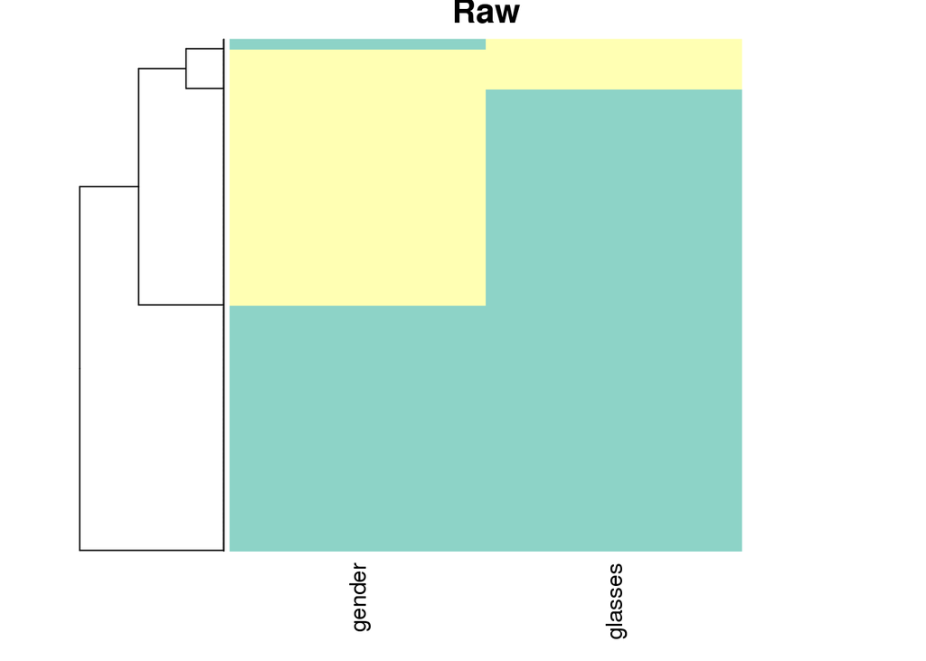

```r
heatmap(mat, scale="none", col=cols, Colv=NA, labRow=NA, Rowv=as.dendrogram(hc.rows), cexCol=1.25, main="Raw")
```

```r
# Predicted vals
mat <- sapply(1:ncol(predclasses), function(i) as.numeric(factor(predclasses[,i], levels=levels(rawclasses[,i]))))
colnames(mat) <- colnames(predclasses)
cols <- brewer.pal(max(mat), "Set3")[1:ncol(mat)]
```

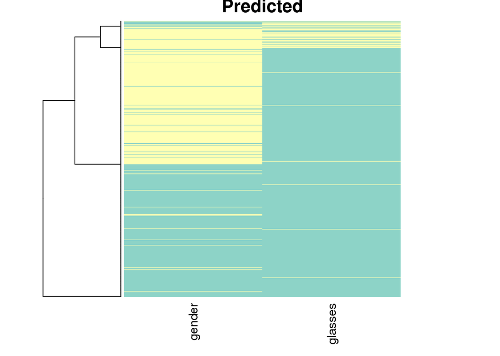

```r
heatmap(mat, scale="none", col=cols, Colv=NA, labRow=NA, Rowv=as.dendrogram(hc.rows), cexCol=1.25, main="Predicted")
```

```r
predprobs2 <- predprobs <- data.frame(sapply(cvrep.binomial, function(x) x$fitted))
residprobs2 <- residprobs <- data.frame(sapply(cvrep.binomial, function(x) x$resids))
mn.cnames2 <- mn.cnames <- unlist(lapply(names(cvrep.binomial), function(x) levels(df2[[x]])))
head(predprobs)
```

```
##        gender      glasses
## 1 0.908592023 0.5827925515
## 2 0.975787097 0.0014645177
## 3 0.008135049 0.0004605661
## 4 0.652969153 0.0010285068
## 5 0.111673404 0.0002479226
## 6 0.974294047 0.0022205850
```

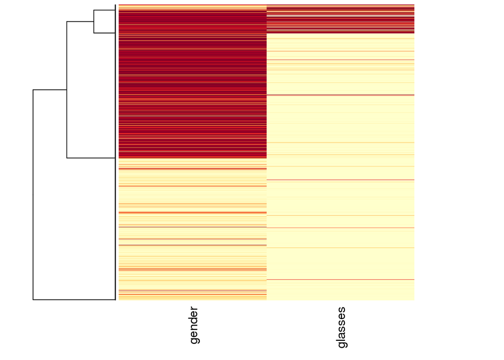

```r
cols <- colorRampPalette(brewer.pal(9, "YlOrRd"))(100)
mat <- as.matrix(predprobs)
zlim <- c(0,1)
heatmap(mat, scale="none", col=cols,
        zlim=zlim, Colv=NA, labRow=NA, Rowv=as.dendrogram(hc.rows),
        margins=c(5,5), cexCol = 1.25)
```

## Save

Finally save the needed things. Rename the variables and save.

```r
res.gaussian <- list(
  rsqs = rsqs,
  predvals = predvals,
  residvals = residvals
)

res.multinomial <- list(
  accuracy = df.acc1,
  predclass = predclasses1,
  rawclass = rawclasses1,
  predprobs = predprobs1,
  residprobs = residprobs1,
  cnames = mn.cnames1
)

res.binomial <- list(
  accuracy = df.acc2,
  predclass = predclasses2,
  rawclass = rawclasses2,
  predprobs = predprobs2,
  residprobs = residprobs2,
  cnames = mn.cnames2
)

save(vnames, res.gaussian, res.multinomial, res.binomial, file="/data1/famface01/analysis/misc/320_roi_task_activity/41_predictors.rda")
```